# Week 6 Tidying Data

#Functions Example

```r
pow(9,0)
```

```
[1] "9 raised to the power 0 is 1"
```

```r
#With default value
pow <- function(x, y = 2) {
    # function to print x raised to the power y
    result <- x^y
    print(paste(x,"raised to the power", y, "is", result))
}

pow(5)

pheatmap

#Can you write a function to add, subtract and multiple? Can you also make the function to print the results out?
```

[output not shown]

# Part One - UBS

```r
library(alr4)
library(tidyverse)
library(ggplot2)
```

```r
UBSprices <- as.data.frame(UBSprices)
head(UBSprices)
```

|  | bigmac2009 | bread2009 | rice2009 | bigmac2003 | bread2003 | rice2003 |
| --- | --- | --- | --- | --- | --- | --- |
| Amsterdam | 19 | 10 | 11 | 16 | 9 | 9 |
| Athens | 30 | 13 | 27 | 21 | 12 | 19 |
| Auckland | 19 | 19 | 13 | 19 | 19 | 9 |
| Bangkok | 45 | 43 | 27 | 50 | 42 | 25 |
| Barcelona | 21 | 17 | 8 | 22 | 19 | 10 |
| Berlin | 19 | 10 | 17 | 16 | 10 | 16 |

# 1. What is the general trend of rice prices in all countries from 2003 to 2009,

# use a boxplot to illustrate your findings

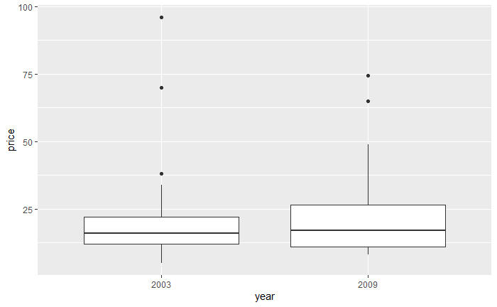

#2. Subset a list of countries that have an increase of rice price from 2003 to 2009? # plot the countries in a bar chart showing the differences in prices # subet another list of countries that have an decrease of price from 2003 to 2009

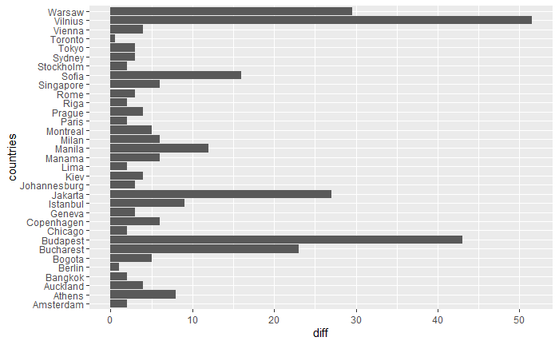

#reordering countries by differences

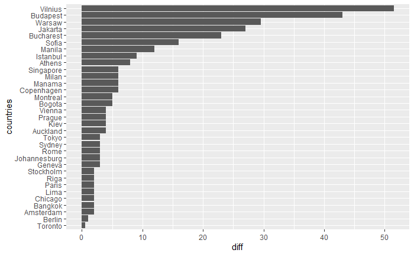

```r
increase_rice$countries <- fct_reorder(increase_rice$countries, increase_rice$diff)

ggplot(data=increase_rice,aes(x=diff,y=countries)) +
  geom_col()
```

## countries with decreased rice price

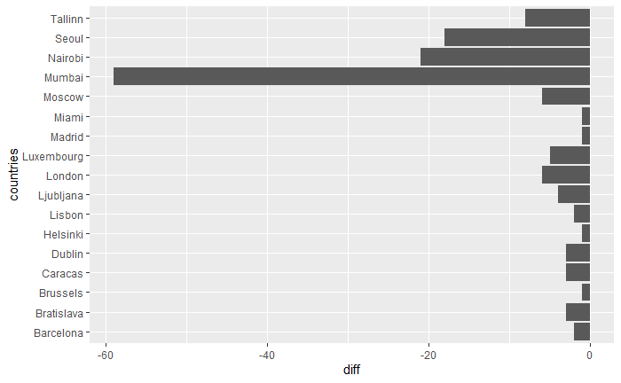

```r
decrease_rice <- tidy_ubs[tidy_ubs$diff<0,]

decrease_rice$countries <- as.factor(rownames(decrease_rice))

ggplot(data=decrease_rice,aes(x=diff,y=countries)) +
  geom_col()
```

# reordering countries by differences

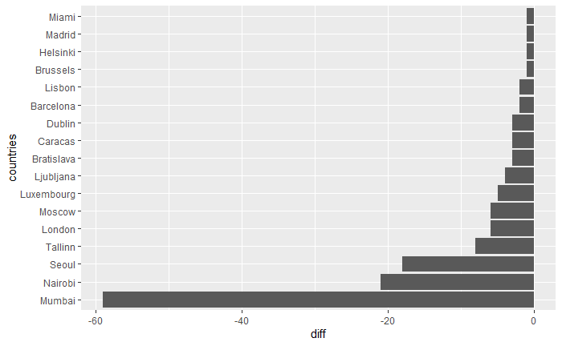

```r
decrease_rice$countries <- fct_reorder(decrease_rice$countries, decrease_rice$diff)

ggplot(data=decrease_rice,aes(x=diff,y=countries)) +
  geom_col()
```

# Part Two - NYC Flights

```r
library(nycflights13)
flights <- flights
str(flights)
```

```
tibble [336,776 x 19] (S3: tbl_df/tbl/data.frame)
 $ year          : int [1:336776] 2013 2013 2013 2013 2013 2013 2013 2013 2013 2013 ...
 $ month         : int [1:336776] 1 1 1 1 1 1 1 1 1 1 ...
 $ day           : int [1:336776] 1 1 1 1 1 1 1 1 1 1 ...
 $ dep_time      : int [1:336776] 517 533 542 544 554 554 555 557 557 558 ...
 $ sched_dep_time: int [1:336776] 515 529 540 545 600 558 600 600 600 600 ...
 $ dep_delay     : num [1:336776] 2 4 2 -1 -6 -4 -5 -3 -3 -2 ...
 $ arr_time      : int [1:336776] 830 850 923 1004 812 740 913 709 838 753 ...
 $ sched_arr_time: int [1:336776] 819 830 850 1022 837 728 854 723 846 745 ...
 $ arr_delay     : num [1:336776] 11 20 33 -18 -25 12 19 -14 -8 8 ...
 $ carrier       : chr [1:336776] "UA" "UA" "AA" "B6" ...
 $ flight        : int [1:336776] 1545 1714 1141 725 461 1696 507 5708 79 301 ...
 $ tailnum       : chr [1:336776] "N14228" "N24211" "N619AA" "N804JB" ...
 $ origin        : chr [1:336776] "EWR" "LGA" "JFK" "JFK" ...
 $ dest          : chr [1:336776] "IAH" "IAH" "MIA" "BQN" ...
 $ air_time      : num [1:336776] 227 227 160 183 116 150 158 53 140 138 ...
 $ distance      : num [1:336776] 1400 1416 1089 1576 762 ...
 $ hour          : num [1:336776] 5 5 5 5 6 5 6 6 6 6 ...
 $ minute        : num [1:336776] 15 29 40 45 0 58 0 0 0 0 ...
 $ time_hour     : POSIXct[1:336776], format: "2013-01-01 05:00:00" "2013-01-01 05:00:00" "2013-01-01 05:00:00" "2013-01-01 05:00:00" ...
```

```r
#1 Select all flights in November
nov_flights = flights %>%
                filter(month == 11)

#2 select all flights on 28th of November
nov28 <- flights %>%
                filter(month == 11, day == 28)

#3 Select from the previous condition, only the columns (flight, origin, distance, air_time)
nov28_4 = nov28 %>%
              select(flight, origin, distance, air_time)
```

[output not shown]

Calculate destination delay based on destination, and filter the final output

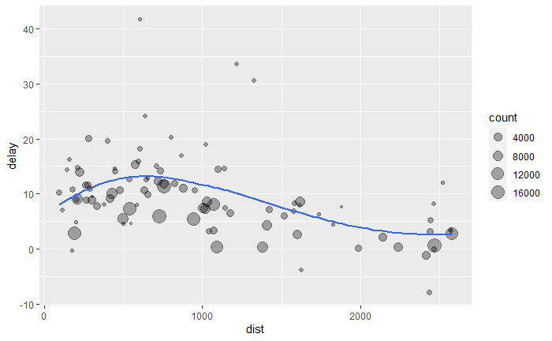

```r
ggplot(data = delays, mapping = aes(x = dist, y = delay)) +
  geom_point(aes(size = count), alpha = 1/3) +
  geom_smooth(se = FALSE)
```

# Real World Example

ParathyroidSE is a dataset from bioconductor that contains a RNA-Seq experiment

```r
#BiocManager::install("parathyroidSE")
library(parathyroidSE)

data(parathyroidGenesSE)
countmatrix <- as.data.frame(parathyroidGenesSE@assays$data$counts)
sample <- as.data.frame(parathyroidGenesSE@colData)
genesname <- as.data.frame(rownames(parathyroidGenesSE))
```